# Week 3 DV 4

Pablo Bello

9/14/2022

# Chapter 4 - Data Visualization

Here, we are going to practice and reinforce some of the key ideas from chapter 4.

## Question 1

We are going to work with a dataset of TV Ratings taken from IMDB. Let’s read it in and see what we have.

```r
library(tidyverse)
# Read in the data
tv_ratings <- read_csv("Data/tv_ratings.csv")
# Glimpse the data
glimpse(tv_ratings)
```

```
## Rows: 2,266
## Columns: 7
## $ titleId      <chr> "tt2879552", "tt3148266", "tt3148266", "tt3148266", "tt31…
## $ seasonNumber <dbl> 1, 1, 2, 3, 4, 1, 2, 1, 2, 3, 4, 5, 6, 7, 8, 1, 1, 1, 1, …
## $ title        <chr> "11.22.63", "12 Monkeys", "12 Monkeys", "12 Monkeys", "12…
## $ date         <date> 2016-03-10, 2015-02-27, 2016-05-30, 2017-05-19, 2018-06-…
## $ av_rating    <dbl> 8.4890, 8.3407, 8.8196, 9.0369, 9.1363, 8.4370, 7.5089, 8…
## $ share        <dbl> 0.51, 0.46, 0.25, 0.19, 0.38, 2.38, 2.19, 6.67, 7.13, 5.8…
## $ genres       <chr> "Drama,Mystery,Sci-Fi", "Adventure,Drama,Mystery", "Adven…
```

We notice that each row is a season-title pair. Then we get the average rating for that season of that show, and the corresponding genre.

The first thing that we are going to look at is how rating develops across seasons, for different genres. To do this, we need shows that have lasted a while. The following bit of code counts how many seasons each show has and then keeps those shows that have had 5 seasons or more.

```r
###--- The TIDY way
tv_long <-
  tv_ratings %>%
  group_by(title) %>%
  summarise(num_seasons = n()) %>%
  ungroup() %>%
  left_join(tv_ratings, by = "title")

tv_long <-
  tv_long %>%
  filter(num_seasons >= 5)

###--- The MEGA-TIDY way
tv_long <-
  tv_ratings |>
  group_by(title) |>
  filter(n() >= 5)

###--- Which should be equivalent to:
tv_long2 <-
  tv_ratings |>
  group_by(title) |>
  filter(max(seasonNumber) >= 5)

nrow(tv_long) == nrow(tv_long2) ###--- But it isn't
```

```
## [1] FALSE
```

```r
###--- Because (amongst other things) there are two different series called Perenthood and two Battlestar Galactica
tv_long |>
  count(title, seasonNumber) |>
  arrange(desc(n))
```

```
## # A tibble: 1,083 × 3
## # Groups:   title [155]
##    title                seasonNumber     n
##    <chr>                       <dbl> <int>
##  1 Battlestar Galactica            1     2
##  2 Parenthood                      1     2
##  3 24                              1     1
##  4 24                              2     1
##  5 24                              3     1
##  6 24                              4     1
##  7 24                              5     1
##  8 24                              6     1
##  9 24                              7     1
## 10 24                              8     1
## # … with 1,073 more rows
```

```r
tv_long |>
  filter(title == "Battlestar Galactica")
```

```
## # A tibble: 5 × 7
## # Groups:   title [1]
##   titleId   seasonNumber title                date       av_rating share genres
##   <chr>            <dbl> <chr>                <date>         <dbl> <dbl> <chr>
## 1 tt0314979            1 Battlestar Galactica 2003-12-08      8.55  0.42 Action…
## 2 tt0407362            1 Battlestar Galactica 2005-02-18      7.94  3.49 Action…
## 3 tt0407362            2 Battlestar Galactica 2005-11-12      7.87  4.66 Action…
## 4 tt0407362            3 Battlestar Galactica 2006-12-25      7.95  2.78 Action…
## 5 tt0407362            4 Battlestar Galactica 2008-09-27      8.44  3.11 Action…
```

```r
tv_long |>
  filter(title == "Parenthood")
```

```
## # A tibble: 7 × 7
## # Groups:   title [1]
##   titleId   seasonNumber title      date       av_rating share genres
##   <chr>            <dbl> <chr>      <date>         <dbl> <dbl> <chr>
## 1 tt0098887            1 Parenthood 1990-11-13      9.68  1.68 Comedy,Drama
## 2 tt1416765            1 Parenthood 2010-04-13      8.06  0.22 Comedy,Drama
## 3 tt1416765            2 Parenthood 2010-12-26      8.32  0.26 Comedy,Drama
## 4 tt1416765            3 Parenthood 2011-12-10      8.59  0.15 Comedy,Drama
## 5 tt1416765            4 Parenthood 2012-11-05      8.70  0.15 Comedy,Drama
## 6 tt1416765            5 Parenthood 2013-12-26      8.49  0.08 Comedy,Drama
## 7 tt1416765            6 Parenthood 2014-11-18      9.00  0.08 Comedy,Drama
```

```r
###--- So what is going on?
tv_long |>
  group_by(titleId) |>
  summarise(n = n(), s = sum(seasonNumber)) |>
  rowwise() |>
  mutate(i = sum(n:1))
```

```
## # A tibble: 157 × 4
## # Rowwise:
##    titleId       n     s     i
##    <chr>     <int> <dbl> <int>
##  1 tt0086765     7    63    28
##  2 tt0092359     6    33    21
##  3 tt0094540     8    52    36
##  4 tt0098844    20   210   210
##  5 tt0098887     1     1     1
##  6 tt0103352     7    28    28
##  7 tt0105946     5    15    15
##  8 tt0105958     7    28    28
##  9 tt0106028     5    16    15
## 10 tt0106145     7    28    28
## # … with 147 more rows
```

```r
###---- Ahhhh,there are missing seasons
tv_long |>
  filter(titleId == "tt0086765")
```

```
## # A tibble: 7 × 7
## # Groups:   title [1]
##   titleId   seasonNumber title             date       av_rating share genres
##   <chr>            <dbl> <chr>             <date>         <dbl> <dbl> <chr>
## 1 tt0086765            6 Murder, She Wrote 1990-01-07      7.87  2.44 Crime,Dra…
## 2 tt0086765            7 Murder, She Wrote 1991-01-28      8.05  2.7  Crime,Dra…
## 3 tt0086765            8 Murder, She Wrote 1991-12-26      7.93  2.93 Crime,Dra…
## 4 tt0086765            9 Murder, She Wrote 1993-01-06      7.78  3.6  Crime,Dra…
## 5 tt0086765           10 Murder, She Wrote 1993-12-22      7.92  1.8  Crime,Dra…
## 6 tt0086765           11 Murder, She Wrote 1994-12-22      7.76  0.45 Crime,Dra…
## 7 tt0086765           12 Murder, She Wrote 1996-01-07      8.02  0.63 Crime,Dra…
```

```r
###--- The this one method is best
tv_long <-
  tv_ratings |>
  group_by(title) |>
  filter(n() >= 5)
```

Use `tv_long` to make a line plot to trace how average ratings evolve across seasons. Remember to use the group aesthetic so that each line represents one show.

It should look fairly messy. Can you draw any conclusions from it?

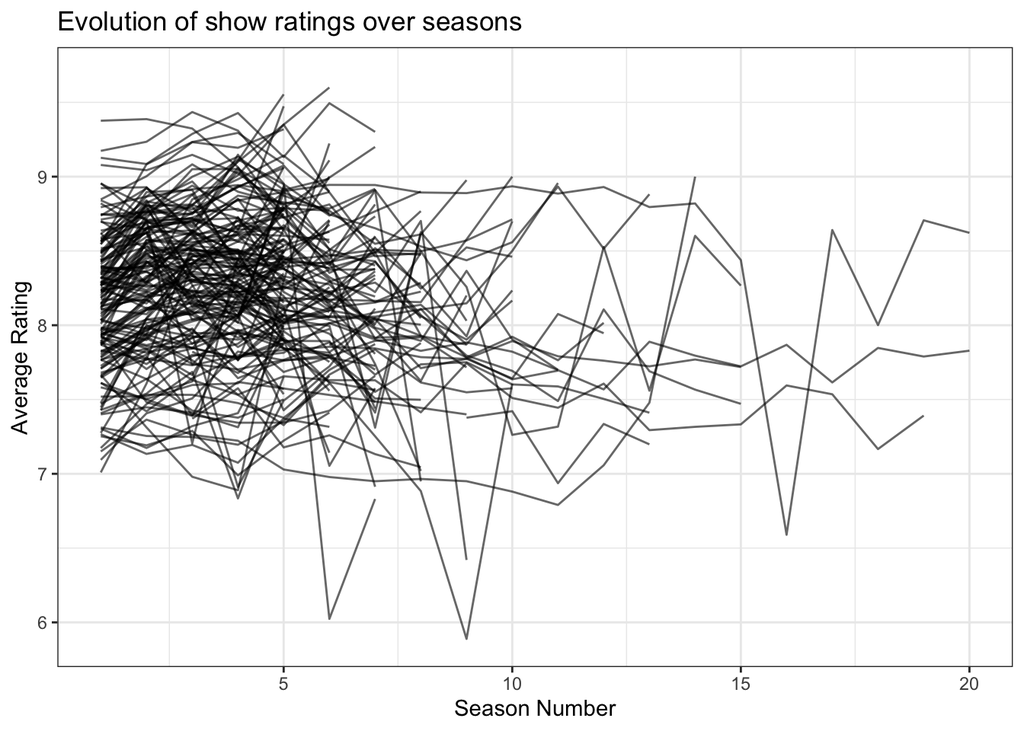

```r
(p1 <-
  tv_long |>
  ggplot(aes(seasonNumber,av_rating, group = titleId)) +
  geom_line(alpha = .6) +
  theme_bw() +
  labs(x = "Season Number",
       y = "Average Rating",
       title = "Evolution of show ratings over seasons"))
```

**It is pretty messy. The conclusion would be that there isn’t a clear trend across shows of how ratings evolve.**

## Question 2

Facet the plot above by `genres` so that we can see patterns more clearly.

What shows tend to last longer? Do ratings change much across seasons? Can you identify that show on `Drama, Family, Fantasy` whose ratings just plummeted?

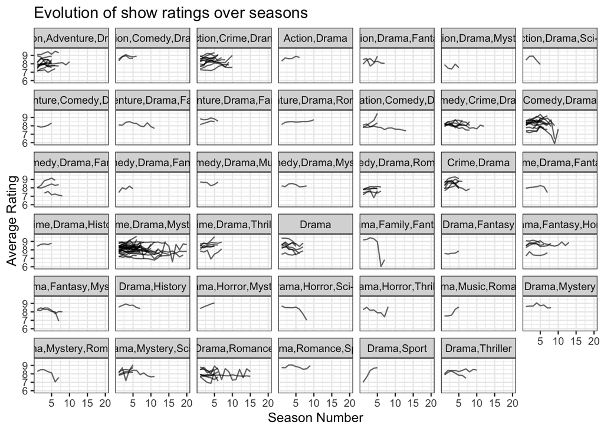

```r
p1 +
  facet_wrap(~ genres)
```

```r
###--- the show that plumets
tv_long |>
  filter(genres == "Drama,Family,Fantasy") |>
  distinct(title) |>
  pull(title)
```

```
## [1] "Are You Afraid of the Dark?"
```

## Question 3

Let’s look at the `genres` that show up in the best rated shows.

First, filter the original data set - `tv_ratings` - so that it only includes rows where the average rating is higher or equal than 9.

```r
(top_tv <-
  tv_ratings |>
  filter(av_rating >= 9))
```

```
## # A tibble: 93 × 7
##    titleId   seasonNumber title          date       av_rating share genres
##    <chr>            <dbl> <chr>          <date>         <dbl> <dbl> <chr>
##  1 tt3148266            3 12 Monkeys     2017-05-19      9.04  0.19 Adventure,D…
##  2 tt3148266            4 12 Monkeys     2018-06-26      9.14  0.38 Adventure,D…
##  3 tt3488298            2 American Crime 2016-02-03      9.14  0.17 Crime,Drama
##  4 tt0103352            1 Are You Afrai… 1993-04-17      9.17  8.27 Drama,Famil…
##  5 tt0103352            2 Are You Afrai… 1993-08-10      9.24  6.98 Drama,Famil…
##  6 tt0103352            3 Are You Afrai… 1994-02-23      9.43  2.6  Drama,Famil…
##  7 tt0103352            4 Are You Afrai… 1994-11-18      9.31  2.15 Drama,Famil…
##  8 tt2177489            5 Baby Daddy     2016-05-04      9.14  0.01 Comedy,Dram…
##  9 tt2017109            3 Banshee        2015-02-09      9.16  0.51 Action,Crim…
## 10 tt2188671            5 Bates Motel    2017-03-23      9.06  0.4  Drama,Horro…
## # … with 83 more rows
```

```r
###--- Since the question is "What is the genre with the most top-rated shows?"
# I'll keep only unique shows that got 9 or more in one of their seasons
# to control for n of seasons.

top_tv <-
  top_tv |>
  distinct(titleId,.keep_all = TRUE)
```

Make a barplot where the x-axis is `genre`.

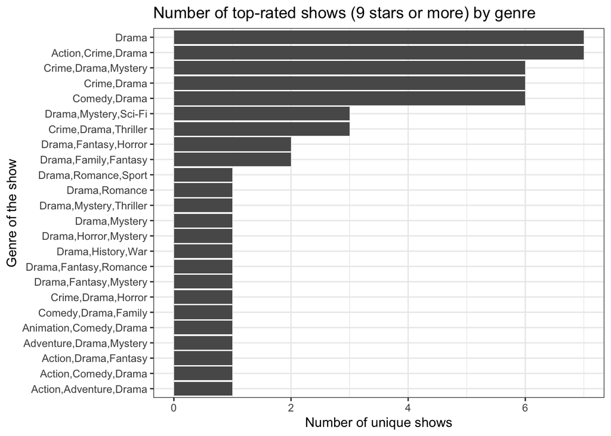

```r
top_tv |>
  count(genres) |>
  mutate(genres = fct_reorder(genres,n)) |>
  ggplot(aes(n,genres)) +
  geom_col() +
  theme_bw() +
  labs(x = "Number of unique shows",
       y = "Genre of the show",
       title = "Number of top-rated shows (9 stars or more) by genre")
```

The result should be hard to read - the names of the genres are quite long. Add `coord_flip()` to the end of your ggplot call and watch the results get clearer. Tell me what `coord_flip()` does.

**Flips the x and y axis.**

What is the genre with the most top-rated shows?

**Drama and “Action,Crime and Drama”.**

## Question 4

As a comedy fan, I am quite distraught by the results. I want to compare the range of average ratings that comedies and dramas get. Surely there are many bad comedies but the best comedies should rival the best dramas. Right?

For this, we need to do a bit of wrangling that I am going to walk you through.

First, because the `genres` names are so convoluted, I am going to classify everything that includes the word “Comedy” as a comedy.

```r
comedies_dramas <-
  tv_ratings %>%
  mutate(is_comedy = if_else(str_detect(genres, "Comedy"), 1, 0)) |>
  filter(is_comedy == 1 | genres == "Drama") |>
  mutate(genres = if_else(genres == "Drama", "Drama", "Comedy"))

glimpse(comedies_dramas)
```

```
## Rows: 684
## Columns: 8
## $ titleId      <chr> "tt0312081", "tt0312081", "tt0312081", "tt1225901", "tt12…
## $ seasonNumber <dbl> 1, 2, 3, 1, 2, 3, 4, 5, 1, 2, 1, 25, 1, 1, 2, 3, 4, 5, 1,…
## $ title        <chr> "8 Simple Rules", "8 Simple Rules", "8 Simple Rules", "90…
## $ date         <date> 2002-09-17, 2003-11-04, 2004-11-12, 2009-01-03, 2009-11-…
## $ av_rating    <dbl> 7.5000, 8.6000, 8.4043, 7.1735, 7.4686, 7.6858, 6.8344, 7…
## $ share        <dbl> 0.03, 0.10, 0.06, 0.40, 0.14, 0.10, 0.04, 0.01, 0.48, 0.4…
## $ genres       <chr> "Comedy", "Comedy", "Comedy", "Comedy", "Comedy", "Comedy…
## $ is_comedy    <dbl> 1, 1, 1, 1, 1, 1, 1, 1, 1, 1, 0, 1, 1, 1, 1, 1, 1, 1, 1, …
```

Now, you should have a dataset with shows that are categorized as either drama or comedies.

Plot a density plot that shows the distribution of average ratings for both comedies and dramas.

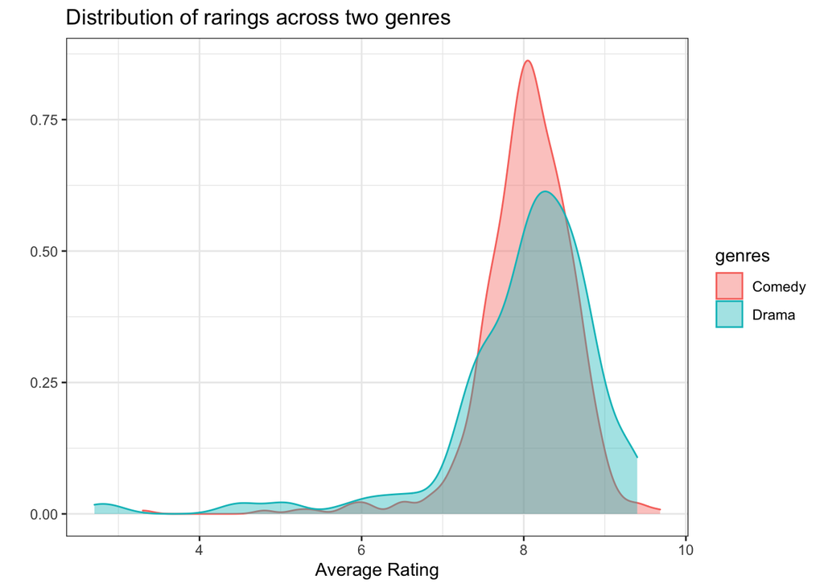

```r
comedies_dramas |>
  ggplot(aes(av_rating,fill = genres, color = genres)) +
  geom_density(alpha = .4, trim = TRUE) + # Since we're looking at the tails i'll trim
  # them in case there is no support.
  theme_bw() +
  labs(x = "Average Rating",
       y = "",
       title = "Distribution of rarings across two genres")
```

How does my prediction above hold? Are dramas rated higher?

**It holds. In fact, the top 3 rated season-shows are all comedies. We can also see in the density plot that the Drama genre does not have support on the highest values of rating.**

```r
comedies_dramas |>
  arrange(desc(av_rating)) |>
  slice_head(n = 10) |>
  select(title, av_rating)
```

```
## # A tibble: 10 × 2
##    title                av_rating
##    <chr>                    <dbl>
##  1 Parenthood                9.68
##  2 BoJack Horseman           9.47
##  3 Greek                     9.4
##  4 L.A. Law                  9.4
##  5 When Calls the Heart      9.39
##  6 Kingdom                   9.38
##  7 When Calls the Heart      9.38
##  8 Suits                     9.35
##  9 When Calls the Heart      9.32
## 10 L.A. Law                  9.3
```

## Question 5

Let’s experiment with different ways of visualizing this. First, do the same plot using histograms.

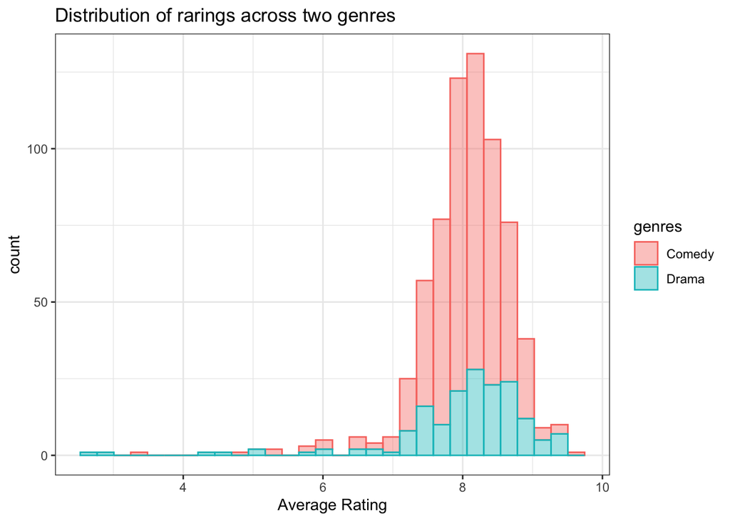

```r
comedies_dramas |>
  ggplot(aes(av_rating,fill = genres, color = genres)) +
  geom_histogram(alpha = .4) +
  theme_bw() +
  labs(x = "Average Rating",
       title = "Distribution of rarings across two genres")
```

What additional information does this give you?

> Hint: look at the size of the bars. I probably categorized way too many shows as “comedies”. I had to stack the deck.

**There are less dramas than comedies.**

Now, use `geom_freqpoly()`. What do you notice? Of the three plots, which one do you think it’s more informative?

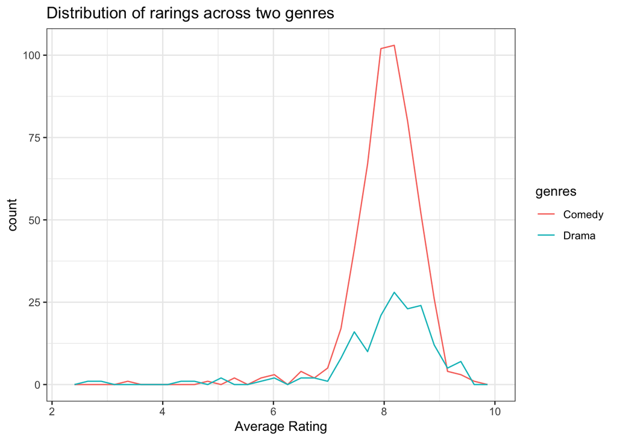

```r
comedies_dramas |>
  ggplot(aes(av_rating,fill = genres, color = genres)) +
  geom_freqpoly() +
  theme_bw() +
  labs(x = "Average Rating",
       title = "Distribution of rarings across two genres")
```

**It’s the siloutte of geom_histogram. In this case geom_density is better if we want to compare distributions, because the number of observations does not affect. Although density plots can many times create illusions so it’s good to look at histograms to know where your observations really are. Even better, a version of the histogram with relative values instead of counts.**

## Question 6

Let’s now explore whether the actual quality of the show corresponded to how many people were paying attention. The column `share` indicates the share of viewership that that show and season acquired. We are going to examine the relationship between average rating and share of viewership.

Take our `comedies_dramas` dataset and make a plot where average rating is on the x-axis and share on the y-axis. Use `geom_bin_2d()` to make the plot.

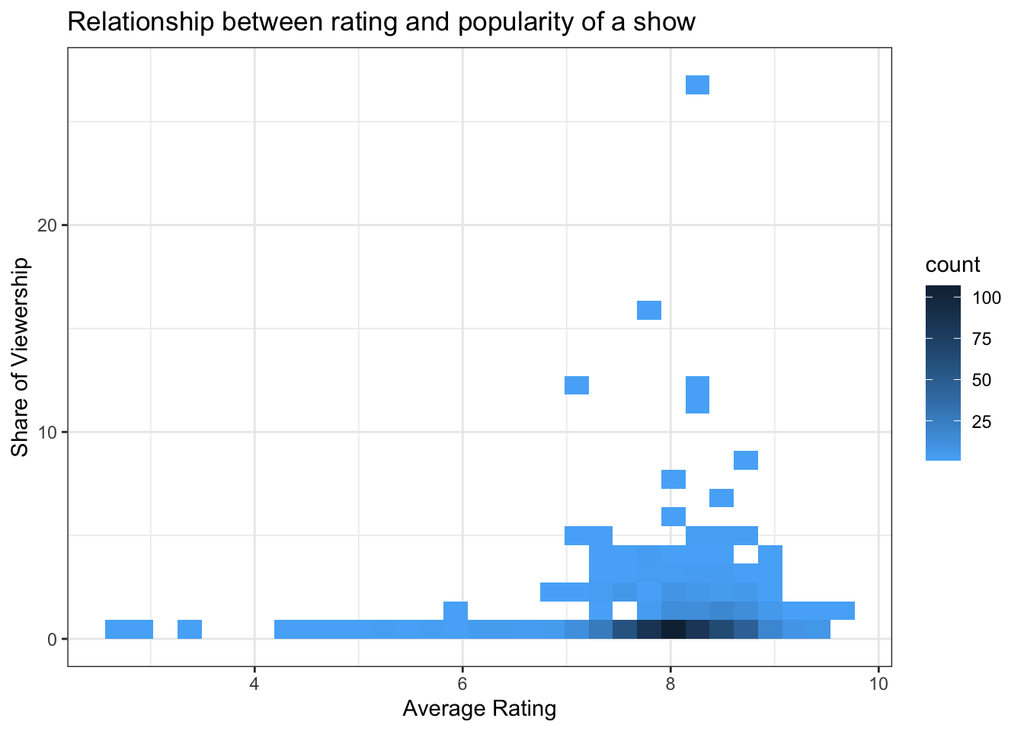

```r
(p2 <-
  comedies_dramas |>
  ggplot(aes(av_rating, share)) +
  geom_bin_2d() +
  scale_fill_continuous(high = "#132B43", low = "#56B1F7") +
   labs(x = "Average Rating",
        y = "Share of Viewership",
        title = "Relationship between rating and popularity of a show") +
    theme_bw()) # reverse the scale
```

```r
# More intuitive to me if darker where there are MORE observations.
```

What do you see? What additional information does this give you in comparison to a scatter plot? **Because there are many data points and they are over-plotted, geom_bin_2d breaks the grid into discrete units and counts the number of observations on each. The number of observations is then presented as color. Akin to geom_point (alpha = a low value)**

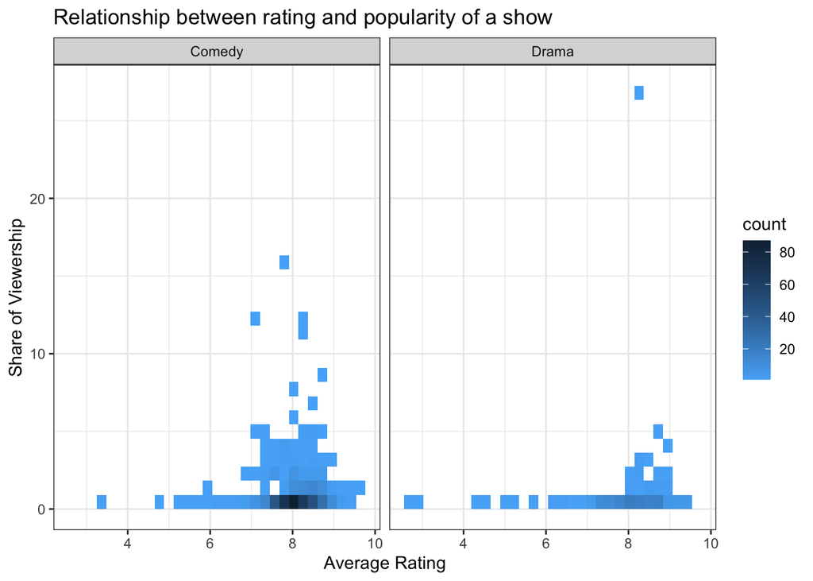

```r
p2 +
  facet_wrap(~ genres)
```

```r
###--- Who's the outlier?
comedies_dramas |>
  filter(share == max(share)) |>
  pull(title)
```

```
## [1] "Dekalog"
```

Now add `genres` to the fill aesthetic. What patterns do you see? Can you identify that big outlier that apparently captured the nation?

**Again there are less drama shows so it is difficult to compare. We can say that there are more highly popular comedy shows (e.g. above 10% of viewership). For both genres rating and viewership are just weakly related. The big outlier was Dekalog.**